# Semana 1 - Limpieza de datos

Nicolás Llerena

09 de enero, 2026

# 1 Instalar librerias

CTRL + ALT + i: Combinación de teclas para abrir un chunk.

```r
# install.packages("dplyr")

library(dplyr)  # Llamar la librería
```

# 2 Cargar los datos

## 2.1 Desde un Excel

```r
rm(list = ls()) # Borra todos los values
```

```r
library(readxl)  # Llama la librería que carga los datos desde un Excel
Datos_Diversos <- read_excel("Datos_Diversos_Pasado.xlsx") # Cargar los datos
head(Datos_Diversos)  # Llama las 6 primeras filas
```

| Período | Código | Apellido | Nombre | Sección | Ciclo | Edad | Estatura (cm) | Peso (kg) | Signo del zodiaco | Sexo | Carrera | Tiempo de reacción | Juega videojuegos | Hace deporte | Color favorito | Talla de zapato | Talla de polo | ...19 | ...20 |
| --- | --- | --- | --- | --- | --- | --- | --- | --- | --- | --- | --- | --- | --- | --- | --- | --- | --- | --- | --- |
| 2020.2 | 201810033 | Chuquimajo Huamantumba | Pablo | 3 | 5 | 21 | 180 | 68 | geminis | M | Ing.Electrónica | 300 | no | no | NA | NA | NA | NA | NA |
| 2020.2 | 201810647 | Abad Rios | Alexandro | 1 | 6 | 19 | 170 | 63 | Géminis | M | Bioingenieria | NA | si | si | NA | NA | NA | NA | NA |
| 2020.1 | 201910052 | Abanto Rodríguez | Diego Walter | 1 | 3 | 17 | 153 | 50 | Escorpio | M | Ing.Mecatronica | 381 | No | No | NA | NA | NA | NA | NA |
| 2020.1 | 201810713 | Acevedo Loayza | Gina Tamarah | 1 | 5 | 18 | 172 | 74 | Aries | F | Ing. Industrial | 381 | no | no | NA | NA | NA | NA | NA |
| 2020.1 | 201910054 | Acevedo Polo | Rodrigo Yonnel | 5 | 3 | 18 | 181 | 81 | Aries | M | Ing. Mecatronica | 332 | Si | Si | NA | NA | NA | NA | NA |
| 2020.2 | 201910056 | Acuña Faustino | Ana Maria | 3 | 4 | 18 | 153 | 55 | Virgo | F | Ing. Mecatrónica | 405 | no | no | NA | NA | NA | 515 | NA |

## 2.2 Desde un CSV

Para comentar varias lineas a la vez, selecciono las lineas y presiono las teclas CTRL + mayùs + c

```r
# library(readr)
# Datos_Diversos_Pasado <- read_csv("Datos_Diversos_Pasado.csv")
# head(Datos_Diversos_Pasado)
```

# 3 Revizar los datos

## 3.1 Resumen general de la tabla de datos

El comando `str` devuelve un resumen del tipo de variable que asume RStudio.

```r
str(Datos_Diversos)
```

```
tibble [1,099 × 20] (S3: tbl_df/tbl/data.frame)
 $ Período           : chr [1:1099] "2020.2" "2020.2" "2020.1" "2020.1" ...
 $ Código            : num [1:1099] 2.02e+08 2.02e+08 2.02e+08 2.02e+08 2.02e+08 ...
 $ Apellido          : chr [1:1099] "Chuquimajo Huamantumba" "Abad Rios" "Abanto Rodríguez" "Acevedo Loayza" ...
 $ Nombre            : chr [1:1099] "Pablo" "Alexandro" "Diego Walter" "Gina Tamarah" ...
 $ Sección           : num [1:1099] 3 1 1 1 5 3 3 1 3 3 ...
 $ Ciclo             : chr [1:1099] "5" "6" "3" "5" ...
 $ Edad              : num [1:1099] 21 19 17 18 18 18 17 22 17 18 ...
 $ Estatura (cm)     : num [1:1099] 180 170 153 172 181 153 160 177 166 165 ...
 $ Peso (kg)         : chr [1:1099] "68" "63" "50" "74" ...
 $ Signo del zodiaco : chr [1:1099] "geminis" "Géminis" "Escorpio" "Aries" ...
 $ Sexo              : chr [1:1099] "M" "M" "M" "F" ...
 $ Carrera           : chr [1:1099] "Ing.Electrónica" "Bioingenieria" "Ing.Mecatronica" "Ing. Industrial" ...
 $ Tiempo de reacción: chr [1:1099] "300" NA "381" "381" ...
 $ Juega videojuegos : chr [1:1099] "no" "si" "No" "no" ...
 $ Hace deporte      : chr [1:1099] "no" "si" "No" "no" ...
 $ Color favorito    : chr [1:1099] NA NA NA NA ...
 $ Talla de zapato   : chr [1:1099] NA NA NA NA ...
 $ Talla de polo     : chr [1:1099] NA NA NA NA ...
 $ ...19             : num [1:1099] NA NA NA NA NA ...
 $ ...20             : chr [1:1099] NA NA NA NA ...
```

## 3.2 Resumen de una sola variable

Resumen de una variable cuantitativa o numérica

```r
summary(Datos_Diversos$Edad)
```

```
   Min. 1st Qu.  Median    Mean 3rd Qu.    Max.    NA's
   7.00   18.00   19.00   19.38   20.00   53.00      10
```

Resumen de una variable cualitativa

```r
table(Datos_Diversos$Sexo, useNA = "always")
```

```
  70    F    m    M   mM   NB <NA>
   1  274    2  810    1    1   10
```

## 3.3 Revizar el inicio y el final de los datos

```r
# Lee las 6 primeras filas de la base de datos
head(Datos_Diversos)
```

| Período | Código | Apellido | Nombre | Sección | Ciclo | Edad | Estatura (cm) | Peso (kg) | Signo del zodiaco | Sexo | Carrera | Tiempo de reacción | Juega videojuegos | Hace deporte | Color favorito | Talla de zapato | Talla de polo | ...19 | ...20 |
| --- | --- | --- | --- | --- | --- | --- | --- | --- | --- | --- | --- | --- | --- | --- | --- | --- | --- | --- | --- |
| 2020.2 | 201810033 | Chuquimajo Huamantumba | Pablo | 3 | 5 | 21 | 180 | 68 | geminis | M | Ing.Electrónica | 300 | no | no | NA | NA | NA | NA | NA |
| 2020.2 | 201810647 | Abad Rios | Alexandro | 1 | 6 | 19 | 170 | 63 | Géminis | M | Bioingenieria | NA | si | si | NA | NA | NA | NA | NA |
| 2020.1 | 201910052 | Abanto Rodríguez | Diego Walter | 1 | 3 | 17 | 153 | 50 | Escorpio | M | Ing.Mecatronica | 381 | No | No | NA | NA | NA | NA | NA |
| 2020.1 | 201810713 | Acevedo Loayza | Gina Tamarah | 1 | 5 | 18 | 172 | 74 | Aries | F | Ing. Industrial | 381 | no | no | NA | NA | NA | NA | NA |
| 2020.1 | 201910054 | Acevedo Polo | Rodrigo Yonnel | 5 | 3 | 18 | 181 | 81 | Aries | M | Ing. Mecatronica | 332 | Si | Si | NA | NA | NA | NA | NA |
| 2020.2 | 201910056 | Acuña Faustino | Ana Maria | 3 | 4 | 18 | 153 | 55 | Virgo | F | Ing. Mecatrónica | 405 | no | no | NA | NA | NA | 515 | NA |

```r
# Lee las 6 últimas filas de la base de datos
tail(Datos_Diversos)
```

| Período | Código | Apellido | Nombre | Sección | Ciclo | Edad | Estatura (cm) | Peso (kg) | Signo del zodiaco | Sexo | Carrera | Tiempo de reacción | Juega videojuegos | Hace deporte | Color favorito | Talla de zapato | Talla de polo | ...19 | ...20 |
| --- | --- | --- | --- | --- | --- | --- | --- | --- | --- | --- | --- | --- | --- | --- | --- | --- | --- | --- | --- |
| 2022-1 | 202010163 | Ramirez Frias | Juan Manuel | 1 | 5 | 20 | 1.75 | 75 | Escorpio | M | Ing.Civil | 235 | si | si | azul | 43 | M | NA | NA |
| 2022-1 | 202210288 | Rivera Alagon | Melisa Karen | 1 | 2 | 17 | 158.00 | 54 | Geminis | F | Ciencias de la computación | 220 | No | No | Azul | 37 | S | NA | NA |
| 2021-2 | 202120635 | Espinoza Portillo | Gean Franco Gilberto | 13 | 3 | 21 | 1.67 | 54 | Virgo | M | Bioingeniería | NA | si | si | Verde | 41 | S | NA | NA |
| 2021-2 | 202020139 | Salazar Meza | Leslie Allison | 4 | 3 | 19 | 1.60 | 50 | Aries | F | Ing. Industrial | 437 | si | no | Guinda | 36 | M | NA | NA |
| 2021-1 | 202110739 | Guerra Rios | Daniela Andrea | 14 | 5 | 20 | 1.59 | 50 | tauro | F | Ing.Civil | 345 | no | si | Rojo | 37 | S | NA | NA |
| NA | NA | NA | NA | NA | NA | NA | NA | NA | NA | NA | NA | 47 | NA | NA | NA | NA | NA | NA | NA |

```r
# Pedir ayuda al R
help(mean)
```

# 4 Limpieza de los datos

## 4.1 Datos incompletos / completos

`is.na()`: Este comando detecta los datos incompletos (NA).  
`sum`: Suma la cantidad de datos incompletos.  
`!`: Es el operador negación

TRUE = 1  
FALSE = 0

```r
TRUE + 1
```

```
[1] 2
```

```r
FALSE + 1
```

```
[1] 1
```

```r
TRUE + TRUE
```

```
[1] 2
```

```r
TRUE + FALSE
```

```
[1] 1
```

```r
!FALSE
```

```
[1] TRUE
```

```r
# Cantidad de datos nulos (NA) /incompletos
sum(is.na(Datos_Diversos))
```

```
[1] 4187
```

```r
# Cantidad de datos COMPLETOS
sum(!is.na(Datos_Diversos))
```

```
[1] 17793
```

```r
# Datos incompletos + datos COMPLETOS
sum(is.na(Datos_Diversos)) + sum(!is.na(Datos_Diversos))
```

```
[1] 21980
```

```r
1099 * 20
```

```
[1] 21980
```

## 4.2 Columna o variable con datos completos / imcompletos

```r
# Datos incompletos
sum(is.na(Datos_Diversos$Edad))
```

```
[1] 10
```

```r
# Datos COMPLETOS
sum(!is.na(Datos_Diversos$Edad))
```

```
[1] 1089
```

## 4.3 Filas (observaciones o casos) completos / imcompletos

```r
# Cantidad de casos o filas completas
sum(complete.cases(Datos_Diversos))
```

```
[1] 0
```

```r
# Cantidad de casos o filas INcompletas
sum(!complete.cases(Datos_Diversos))
```

```
[1] 1099
```

## 4.4 Criterios para limpieza de datos

**¿Qué hacer si encontramos una casilla vacía o *(N/A)* o caso incompleto o NULL?**

- Eliminar a la observación que no sea un **caso completo**. La desventaja es que se puede perder información de otras variables que si son importantes, además de incrementar ligeramente el sesgo ya existente.
- Ver cual es la variable o columna que tiene la mayor cantidad de datos incompletos y eliminarlo
- Re-consultar la fuente y completar la información con el valor verídico.
- **No se debe** completar la información a criterio o al azar, pues se estaría manipulando intencionalmente la información, lo cual no es éticamente correcto.

**¿Qué hacer si encontramos una casilla con un valor evidentemente erróneo?**

- Eliminar la observación (*ya se explicó sus desventajas*), depende de la cantidad de estas observaciones.
- Corregir el valor, por el adecuado; para esto podemos consultar con la fuente original (**es lo ideal**), o corregirlo a criterio siempre y cuando el error sea **muy evidente**.

## 4.5 Librería dplyr

- Paquete con pocas funciones pero muy poderosas para ordenar datos
- Parte del tidyverse (Colección de paquetes disponibles en R y orientados a la **manipulación, importación, exploración y visualización de datos**, que se utiliza exhaustivamente en ciencia de datos)
  - **rename**: Cambia los nombre de las columnas de una base.
  - **group_by**: (agrupa datos)
  - **summarize**: (resume datos agrupados)
  - **filter**: (Encuentra filas con ciertas condiciones)
  - **select**: junto a **starts_with, ends_with o contains**, selecciona columnas.
  - **mutate**: (Genera variables nuevas).
  - **%>%**: pipeline es un operador (CTRL + SHIFT + m)
  - **arrange**: ordenar

```r
# install.packages("dplyr")   # Instala una librería
library(dplyr)                # Llamar la librería
```

### 4.5.1 Funcion “rename”

Cambia los nombre de las columnas de una base de datos.

`rename(base_datos, nombrenuevo1 = nombreviejo1, nombrenuevo2 = nombreviejo2, ... )`

```r
# Listando los encabezados
names(Datos_Diversos)
```

```
 [1] "Período"            "Código"
 [3] "Apellido"           "Nombre"
 [5] "Sección"            "Ciclo"
 [7] "Edad"               "Estatura (cm)"
 [9] "Peso (kg)"          "Signo del zodiaco"
[11] "Sexo"               "Carrera"
[13] "Tiempo de reacción" "Juega videojuegos"
[15] "Hace deporte"       "Color favorito"
[17] "Talla de zapato"    "Talla de polo"
[19] "...19"              "...20"
```

```r
Datos_Diversos_rename <- rename(Datos_Diversos,  # Tabla de datos
                                Periodo = Período
                                ,Codigo = Código
                                ,Seccion = Sección
                                ,Estatura = "Estatura (cm)"
                                ,Peso = "Peso (kg)"
                                ,Signo = "Signo del zodiaco"
                                ,Tiempo = "Tiempo de reacción"
                                ,Videojuegos = "Juega videojuegos"
                                ,Deporte = "Hace deporte"
                                ,Color = "Color favorito"
                                ,Calzado = "Talla de zapato"
                                ,Polo = "Talla de polo"
                                 )
```

```r
names(Datos_Diversos_rename)
```

```
 [1] "Periodo"     "Codigo"      "Apellido"
 [4] "Nombre"      "Seccion"     "Ciclo"
 [7] "Edad"        "Estatura"    "Peso"
[10] "Signo"       "Sexo"        "Carrera"
[13] "Tiempo"      "Videojuegos" "Deporte"
[16] "Color"       "Calzado"     "Polo"
[19] "...19"       "...20"
```

### 4.5.2 Funcion “select”

- Permite ir rápidamente a un subconjunto mediante operaciones basadas en el nombre de las variables.
- Es útil si se tiene data con muchas variables.

`select(base_datos, variables_a_seleccionar)`

```r
head(Datos_Diversos_rename)
```

| Periodo | Codigo | Apellido | Nombre | Seccion | Ciclo | Edad | Estatura | Peso | Signo | Sexo | Carrera | Tiempo | Videojuegos | Deporte | Color | Calzado | Polo | ...19 | ...20 |
| --- | --- | --- | --- | --- | --- | --- | --- | --- | --- | --- | --- | --- | --- | --- | --- | --- | --- | --- | --- |
| 2020.2 | 201810033 | Chuquimajo Huamantumba | Pablo | 3 | 5 | 21 | 180 | 68 | geminis | M | Ing.Electrónica | 300 | no | no | NA | NA | NA | NA | NA |
| 2020.2 | 201810647 | Abad Rios | Alexandro | 1 | 6 | 19 | 170 | 63 | Géminis | M | Bioingenieria | NA | si | si | NA | NA | NA | NA | NA |
| 2020.1 | 201910052 | Abanto Rodríguez | Diego Walter | 1 | 3 | 17 | 153 | 50 | Escorpio | M | Ing.Mecatronica | 381 | No | No | NA | NA | NA | NA | NA |
| 2020.1 | 201810713 | Acevedo Loayza | Gina Tamarah | 1 | 5 | 18 | 172 | 74 | Aries | F | Ing. Industrial | 381 | no | no | NA | NA | NA | NA | NA |
| 2020.1 | 201910054 | Acevedo Polo | Rodrigo Yonnel | 5 | 3 | 18 | 181 | 81 | Aries | M | Ing. Mecatronica | 332 | Si | Si | NA | NA | NA | NA | NA |
| 2020.2 | 201910056 | Acuña Faustino | Ana Maria | 3 | 4 | 18 | 153 | 55 | Virgo | F | Ing. Mecatrónica | 405 | no | no | NA | NA | NA | 515 | NA |

```r
# Forma de selección 1
head(select(Datos_Diversos_rename, Periodo, Edad, Ciclo))
```

| Periodo | Edad | Ciclo |
| --- | --- | --- |
| 2020.2 | 21 | 5 |
| 2020.2 | 19 | 6 |
| 2020.1 | 17 | 3 |
| 2020.1 | 18 | 5 |
| 2020.1 | 18 | 3 |
| 2020.2 | 18 | 4 |

Con Pipe `%>%` o `|>` CTRL + SHIFT + m

```r
select(Datos_Diversos_rename, Periodo, Edad, Ciclo) |>  # 1. Aplico la función select
  head()    # 2. Selecciono las primeras 6 filas
```

| Periodo | Edad | Ciclo |
| --- | --- | --- |
| 2020.2 | 21 | 5 |
| 2020.2 | 19 | 6 |
| 2020.1 | 17 | 3 |
| 2020.1 | 18 | 5 |
| 2020.1 | 18 | 3 |
| 2020.2 | 18 | 4 |

```r
# Forma de selección 2
select(Datos_Diversos_rename, 1, 2, 3, 4) |>
  head()
```

| Periodo | Codigo | Apellido | Nombre |
| --- | --- | --- | --- |
| 2020.2 | 201810033 | Chuquimajo Huamantumba | Pablo |
| 2020.2 | 201810647 | Abad Rios | Alexandro |
| 2020.1 | 201910052 | Abanto Rodríguez | Diego Walter |
| 2020.1 | 201810713 | Acevedo Loayza | Gina Tamarah |
| 2020.1 | 201910054 | Acevedo Polo | Rodrigo Yonnel |
| 2020.2 | 201910056 | Acuña Faustino | Ana Maria |

```r
# Forma de selección 3
select(Datos_Diversos_rename, Periodo:Nombre) |>    # Selecciono desde Periodo HASTA Nombre
  head()
```

| Periodo | Codigo | Apellido | Nombre |
| --- | --- | --- | --- |
| 2020.2 | 201810033 | Chuquimajo Huamantumba | Pablo |
| 2020.2 | 201810647 | Abad Rios | Alexandro |
| 2020.1 | 201910052 | Abanto Rodríguez | Diego Walter |
| 2020.1 | 201810713 | Acevedo Loayza | Gina Tamarah |
| 2020.1 | 201910054 | Acevedo Polo | Rodrigo Yonnel |
| 2020.2 | 201910056 | Acuña Faustino | Ana Maria |

```r
# Forma de selección 4
select(Datos_Diversos_rename, 1:4) |>   # Selecciono desde la columna 1 HASTA el 4.
  head()
```

| Periodo | Codigo | Apellido | Nombre |
| --- | --- | --- | --- |
| 2020.2 | 201810033 | Chuquimajo Huamantumba | Pablo |
| 2020.2 | 201810647 | Abad Rios | Alexandro |
| 2020.1 | 201910052 | Abanto Rodríguez | Diego Walter |
| 2020.1 | 201810713 | Acevedo Loayza | Gina Tamarah |
| 2020.1 | 201910054 | Acevedo Polo | Rodrigo Yonnel |
| 2020.2 | 201910056 | Acuña Faustino | Ana Maria |

```r
# Forma de selección 5: Selecciono toda la tabla, menos la columna 2.
select(Datos_Diversos_rename, -2) |>
  head()
```

| Periodo | Apellido | Nombre | Seccion | Ciclo | Edad | Estatura | Peso | Signo | Sexo | Carrera | Tiempo | Videojuegos | Deporte | Color | Calzado | Polo | ...19 | ...20 |
| --- | --- | --- | --- | --- | --- | --- | --- | --- | --- | --- | --- | --- | --- | --- | --- | --- | --- | --- |
| 2020.2 | Chuquimajo Huamantumba | Pablo | 3 | 5 | 21 | 180 | 68 | geminis | M | Ing.Electrónica | 300 | no | no | NA | NA | NA | NA | NA |
| 2020.2 | Abad Rios | Alexandro | 1 | 6 | 19 | 170 | 63 | Géminis | M | Bioingenieria | NA | si | si | NA | NA | NA | NA | NA |
| 2020.1 | Abanto Rodríguez | Diego Walter | 1 | 3 | 17 | 153 | 50 | Escorpio | M | Ing.Mecatronica | 381 | No | No | NA | NA | NA | NA | NA |
| 2020.1 | Acevedo Loayza | Gina Tamarah | 1 | 5 | 18 | 172 | 74 | Aries | F | Ing. Industrial | 381 | no | no | NA | NA | NA | NA | NA |
| 2020.1 | Acevedo Polo | Rodrigo Yonnel | 5 | 3 | 18 | 181 | 81 | Aries | M | Ing. Mecatronica | 332 | Si | Si | NA | NA | NA | NA | NA |
| 2020.2 | Acuña Faustino | Ana Maria | 3 | 4 | 18 | 153 | 55 | Virgo | F | Ing. Mecatrónica | 405 | no | no | NA | NA | NA | 515 | NA |

```r
select(Datos_Diversos_rename, 1:18) |>
  head()
```

| Periodo | Codigo | Apellido | Nombre | Seccion | Ciclo | Edad | Estatura | Peso | Signo | Sexo | Carrera | Tiempo | Videojuegos | Deporte | Color | Calzado | Polo |
| --- | --- | --- | --- | --- | --- | --- | --- | --- | --- | --- | --- | --- | --- | --- | --- | --- | --- |
| 2020.2 | 201810033 | Chuquimajo Huamantumba | Pablo | 3 | 5 | 21 | 180 | 68 | geminis | M | Ing.Electrónica | 300 | no | no | NA | NA | NA |
| 2020.2 | 201810647 | Abad Rios | Alexandro | 1 | 6 | 19 | 170 | 63 | Géminis | M | Bioingenieria | NA | si | si | NA | NA | NA |
| 2020.1 | 201910052 | Abanto Rodríguez | Diego Walter | 1 | 3 | 17 | 153 | 50 | Escorpio | M | Ing.Mecatronica | 381 | No | No | NA | NA | NA |
| 2020.1 | 201810713 | Acevedo Loayza | Gina Tamarah | 1 | 5 | 18 | 172 | 74 | Aries | F | Ing. Industrial | 381 | no | no | NA | NA | NA |
| 2020.1 | 201910054 | Acevedo Polo | Rodrigo Yonnel | 5 | 3 | 18 | 181 | 81 | Aries | M | Ing. Mecatronica | 332 | Si | Si | NA | NA | NA |
| 2020.2 | 201910056 | Acuña Faustino | Ana Maria | 3 | 4 | 18 | 153 | 55 | Virgo | F | Ing. Mecatrónica | 405 | no | no | NA | NA | NA |

```r
# select(Datos_Diversos_rename, c(-19,-20))
```

```r
Datos_Diversos_rename <- select(Datos_Diversos_rename, 1:18) # "Eliminando" la columna 19 y 20 (vacías)
names(Datos_Diversos_rename)
```

```
 [1] "Periodo"     "Codigo"      "Apellido"
 [4] "Nombre"      "Seccion"     "Ciclo"
 [7] "Edad"        "Estatura"    "Peso"
[10] "Signo"       "Sexo"        "Carrera"
[13] "Tiempo"      "Videojuegos" "Deporte"
[16] "Color"       "Calzado"     "Polo"
```

```r
# Filas completas
sum(complete.cases(Datos_Diversos_rename))
```

```
[1] 474
```

```r
# Filas INcompletas
sum(!complete.cases(Datos_Diversos_rename))
```

```
[1] 625
```

### 4.5.3 Seleccionar columnas/variables por coincidencia o patrones

El comando **select** tiene potencia en base de datos cuyas variables tienen algún patrón en común, en esos casos se pueden utilizar los argumentos:

- Patrón 1: `starts_with("...")`, Variables que comienzan con …
- Patrón 2: `ends_with("...")`, Variables que terminan con …
- Patrón 3: `contains("...")`, Variables que contienen …

```r
# Patrón 1
select(Datos_Diversos_rename, starts_with("c")) |>
  head()
```

| Codigo | Ciclo | Carrera | Color | Calzado |
| --- | --- | --- | --- | --- |
| 201810033 | 5 | Ing.Electrónica | NA | NA |
| 201810647 | 6 | Bioingenieria | NA | NA |
| 201910052 | 3 | Ing.Mecatronica | NA | NA |
| 201810713 | 5 | Ing. Industrial | NA | NA |
| 201910054 | 3 | Ing. Mecatronica | NA | NA |
| 201910056 | 4 | Ing. Mecatrónica | NA | NA |

```r
# Patrón 2
select(Datos_Diversos_rename, ends_with("do")) |>
  head()
```

| Periodo | Apellido | Calzado |
| --- | --- | --- |
| 2020.2 | Chuquimajo Huamantumba | NA |
| 2020.2 | Abad Rios | NA |
| 2020.1 | Abanto Rodríguez | NA |
| 2020.1 | Acevedo Loayza | NA |
| 2020.1 | Acevedo Polo | NA |
| 2020.2 | Acuña Faustino | NA |

```r
# Patron 3
select(Datos_Diversos_rename, contains("po")) |>
  head()
```

| Tiempo | Deporte | Polo |
| --- | --- | --- |
| 300 | no | NA |
| NA | si | NA |
| 381 | No | NA |
| 381 | no | NA |
| 332 | Si | NA |
| 405 | no | NA |

### 4.5.4 Función “filter”

`filter(base_datos, condición)`

- Permite crear o seleccionar subconjuntos de la base con base al resultado de sus variables.
- Algunos operadores numéricos para este argumento son:
  - `>`, `<` mayor que, y menor que
  - `>=`, `=<` mayor o igual que, y menor o igual que
  - `!=`, diferente a
  - `==`, igual a
- También puede utilizar operadores booleanos como:
  - `&` and (Intercepción)
  - `|` or (Unión)
  - `!` no o negacion

**Ejercicio 1**: Seleccionar personas o filas de la sección 11.

```r
filter(Datos_Diversos_rename, Seccion=="11")
```

| Periodo | Codigo | Apellido | Nombre | Seccion | Ciclo | Edad | Estatura | Peso | Signo | Sexo | Carrera | Tiempo | Videojuegos | Deporte | Color | Calzado | Polo |
| --- | --- | --- | --- | --- | --- | --- | --- | --- | --- | --- | --- | --- | --- | --- | --- | --- | --- |
| 2022-1 | 202120151 | Ccorisoncco Merino | Esmeralda | 11 | 2 | 19 | 1.60 | 57 | Tauro | F | Ing. Industrial | 254 | no | Sí | Rojo | 36 | S |
| 2021-2 | 202120587 | Vasquez Yupanqui | Naydelin | 11 | 2 | 19 | 1.60 | 52 | Capricornio | F | Ing. Industrial | 247 | no | si | Rojo | 36 | S |
| 2022-1 | 202120345 | Mamani Pauccara | Redy | 11 | 2 | 17 | 161.00 | 56 | Leo | M | Ing. Industrial | 247 | NO | SI | Negro | 40 | S |
| 2022-1 | 202120505 | Rosales Flores | Cinthia Evelin | 11 | 2 | 20 | 151.00 | 50 | Sagitario | F | Ing.Industrial | 394 | No | Si | Celeste | 36 | S |
| 2022-1 | 202120060 | Alban Pacherrez | Milagros | 11 | 2 | 18 | 1.55 | 56 | Piscis | NA | Ingeniería Industrial | 315 | Sí | No | Verde | 38 | S |
| 2022-1 | 202120244 | Guillermo Coris | Johan Kenedy | 11 | 2 | 19 | 1.69 | 56 | virgo | M | Ingeniería Industrial | 327 | si | si | Negro | 41 | M |
| 2022-1 | 202120103 | Baldeon Rupay | Annie Guadalupe | 11 | 2 | 18 | 164.00 | 70 | Sagitario | F | Ingeniería Industrial | 239 | No | Sí | Rosado | 40 | M |
| 2022-1 | 202120161 | Chura Sánchez | Mayk Chura | 11 | 2 | 18 | 172.00 | 65 | Acuario | M | Ingenieria Industrial | 276 | No | Si | Negro | 41 | M |
| 2022-1 | 202120226 | Gallardo Villa | Edid Jackerine | 11 | 2 | 17 | 157.00 | 55 | Libra | F | Ingeniería Industrial | 281 | No | Si | Lila | 38 | S |
| 2022-1 | 202010170 | Tito Berrocal | Angel Ulises | 11 | 3 | 20 | 1.75 | 85 | Sagitario | M | Ciencia de la Computacion | 205 | SI | NO | Rojo | 41 | M |

[output cut: 34 more lines]

**Ejercicio 2**: Seleccionar personas con edad mayor e igual a 28.

```r
filter(Datos_Diversos_rename, Edad>=28)
```

| Periodo | Codigo | Apellido | Nombre | Seccion | Ciclo | Edad | Estatura | Peso | Signo | Sexo | Carrera | Tiempo | Videojuegos | Deporte | Color | Calzado | Polo |
| --- | --- | --- | --- | --- | --- | --- | --- | --- | --- | --- | --- | --- | --- | --- | --- | --- | --- |
| 2020.2 | 201920121 | Mori Vega | Edden Fredy | 5 | 3 | 31 | 160.00 | 75 | Capricornio | M | Bioingenieria | 228 | si | si | NA | NA | NA |
| 2020.1 | NA | Navarro Flores | Cristina | NA | NA | 45 | 150.00 | 49 | Escorpio | F | NA | 607 | No | No | NA | NA | NA |
| 2020.1 | NA | Quineche | Luis | NA | NA | 39 | 165.00 | 72 | Leo | M | NA | 312 | No | No | NA | NA | NA |
| 2020.1 | NA | Renom | José Miguel | NA | NA | 50 | 180.00 | 110 | Aries | M | NA | 425 | Si | No | NA | NA | NA |
| 2020.2 | NA | Renom Andara | José Miguel | NA | NA | 51 | 180.00 | NA | Aries | M | NA | 269 | Si | No | NA | NA | NA |
| 2020.2 | 202010629 | Valderrama Auccacusi | Indira | 1 | 2 | 28 | 155.00 | 60 | Piscis | F | Ing. Electrónica | 365 | No | Sí | NA | NA | NA |
| 2021-1 | NA | Renom | José Miguel | NA | NA | 52 | 180.00 | NA | aries | M | NA | 329 | si | no | NA | NA | NA |
| 2021-2 | NA | Renom | José Miguel | NA | NA | 52 | 180.00 | NA | Aries | M | NA | 309 | Sí | No | Verde | 11 | XXL |
| 2021-2 | 202110472 | Rudas Ramirez | Jhon Omar | 6 | 3 | 29 | 167.00 | 72 | escorpio | M | Ingenieria Industrial | 282 | SI | SI | AZUL | 41 | M |
| 2020-1 | 2018020016 | rojas suarez | guillermo | 2 | 6 | 28 | 1.78 | 90k | acuario | m | ingenieria ambiental | NA | no | si | plomo | 42 | l |

[output cut: 2 more lines]

**Ejercicio 3**: Seleccionar personas que sean del signo piscis.

```r
# unique: Esta función me permite ver todas las opciones únicas de una variable
unique(Datos_Diversos_rename$Signo)
```

```
 [1] "geminis"     "Géminis"     "Escorpio"
 [4] "Aries"       "Virgo"       "Tauro"
 [7] "Sagitario"   "Acuario"     "Geminis"
[10] "Piscis"      "Capricornio" "Cáncer"
[13] "Cancer"      NA            "Libra"
[16] "libra"       "Leo"         "Arias"
[19] "acuario"     "virgo"       "capricornio"
[22] "Escorpion"   "escorpio"    "Ofiuco"
[25] "Capriornio"  "-"           "piscis"
[28] "Gemenis"     "aries"       "Picis"
[31] "sagitario"   "pisics"      "Pisicis"
[34] "cancer"      "tauro"       "leo"
[37] "Sagitatio"   "170"         "Pisis"
[40] "VIrgo"       "cáncer"      "Desconocido"
[43] "Leo ?"       "picis"       "CApricornio"
```

```r
filter(Datos_Diversos_rename
       ,Signo=="pisics" | Signo=="Pisicis" | Signo=="Picis" | Signo=="Pisis" | Signo=="piscis")
```

| Periodo | Codigo | Apellido | Nombre | Seccion | Ciclo | Edad | Estatura | Peso | Signo | Sexo | Carrera | Tiempo | Videojuegos | Deporte | Color | Calzado | Polo |
| --- | --- | --- | --- | --- | --- | --- | --- | --- | --- | --- | --- | --- | --- | --- | --- | --- | --- |
| 2020.2 | 202010328 | Nieto Lloque | Mauricio Aarón | 2 | 2 | 17 | 163.00 | 47 | piscis | M | Ciencia de la Computación | 321 | si | no | NA | NA | NA |
| 2020.2 | 201910432 | Torres | Rodrigo | 1 | 4 | 19 | 179.00 | 70 | piscis | M | Ing. Industrial | 190 | No | Sí | NA | NA | NA |
| 2021.1 | 201810113 | Bailon Causso | Marco | 1 | 7 | 21 | 172.00 | 74 | Picis | M | Ing. Mecanica | 249 | Si | Si | NA | NA | NA |
| 2021.1 | 201910208 | Lopez Osorio | Luis Eduardo | 2 | 5 | 19 | 181.00 | 112 | pisics | M | civil | 223 | si | no | NA | NA | NA |
| 2021.1 | 202010259 | Garcia Castro | Silvana Nicol | 5 | 3 | 17 | 175.00 | 80 | Pisicis | F | Ingeniería Química | 237 | Sí | Sí | NA | NA | NA |
| 2021-2 | 201810542 | Celedonio Cam | Brandon Wilmer | 1 | 7 | 20 | 175.00 | 71 | piscis | M | Ingenieria Civil | 436 | Si | Si | Azul | 42 | M |
| 2021-2 | 202020044 | Chuquiviguel Zaña | Anshel | 1 | 3 | 18 | 160.00 | 48 | Pisis | M | Ingeniería Civil | 289 | si | si | Rojo | 39 | S |
| 2022-1 | 202120079 | Anchante Altamirano | Esthefany Mirella | 8 | 2 | 20 | 1.68 | 69 | piscis | M | Ing. Industrial | 220 | si | si | lila | 39 | M |
| 2021-1 | 202110741 | Jara Palomino | Stephanie Sara | 10 | 3 | 21 | 160.00 | 55 | Picis | F | Ingenieria Ambiental | NA | Si | Si | violeta | 37 | S |

**Ejercicio 4**: Seleccionar personas que sean del signo piscis con edades de 18 o 21 anios.

```r
# Forma 1
filter(Datos_Diversos_rename
       ,Signo=="pisics" | Signo=="Pisicis" | Signo=="Picis" | Signo=="Pisis" | Signo=="piscis"
       ,Edad==18 | Edad==21)
```

| Periodo | Codigo | Apellido | Nombre | Seccion | Ciclo | Edad | Estatura | Peso | Signo | Sexo | Carrera | Tiempo | Videojuegos | Deporte | Color | Calzado | Polo |
| --- | --- | --- | --- | --- | --- | --- | --- | --- | --- | --- | --- | --- | --- | --- | --- | --- | --- |
| 2021.1 | 201810113 | Bailon Causso | Marco | 1 | 7 | 21 | 172 | 74 | Picis | M | Ing. Mecanica | 249 | Si | Si | NA | NA | NA |
| 2021-2 | 202020044 | Chuquiviguel Zaña | Anshel | 1 | 3 | 18 | 160 | 48 | Pisis | M | Ingeniería Civil | 289 | si | si | Rojo | 39 | S |
| 2021-1 | 202110741 | Jara Palomino | Stephanie Sara | 10 | 3 | 21 | 160 | 55 | Picis | F | Ingenieria Ambiental | NA | Si | Si | violeta | 37 | S |

El argumento `%in%` el cual funciona como una reducción de varios operadores lógicos `or`. Para estructuras más complejas recomiendo utilizar la segunda forma.

```r
#Forma 2
filter(Datos_Diversos_rename,
      Signo %in% c("pisics", "Pisicis", "Picis", "Pisis", "piscis"),
      Edad %in% c(18,21)
      )
```

| Periodo | Codigo | Apellido | Nombre | Seccion | Ciclo | Edad | Estatura | Peso | Signo | Sexo | Carrera | Tiempo | Videojuegos | Deporte | Color | Calzado | Polo |
| --- | --- | --- | --- | --- | --- | --- | --- | --- | --- | --- | --- | --- | --- | --- | --- | --- | --- |
| 2021.1 | 201810113 | Bailon Causso | Marco | 1 | 7 | 21 | 172 | 74 | Picis | M | Ing. Mecanica | 249 | Si | Si | NA | NA | NA |
| 2021-2 | 202020044 | Chuquiviguel Zaña | Anshel | 1 | 3 | 18 | 160 | 48 | Pisis | M | Ingeniería Civil | 289 | si | si | Rojo | 39 | S |
| 2021-1 | 202110741 | Jara Palomino | Stephanie Sara | 10 | 3 | 21 | 160 | 55 | Picis | F | Ingenieria Ambiental | NA | Si | Si | violeta | 37 | S |

# 5 Limpieza de los datos

Cantidad de casos o filas completas

```r
sum(complete.cases(Datos_Diversos_rename))
```

```
[1] 474
```

Cantidad de NA o datos vacíos en cada columna

```r
colSums(is.na(Datos_Diversos_rename))
```

```
    Periodo      Codigo    Apellido      Nombre
         17          24          10           8
    Seccion       Ciclo        Edad    Estatura
         29          20          10          20
       Peso       Signo        Sexo     Carrera
         55          16          10          20
     Tiempo Videojuegos     Deporte       Color
        137          40          47         500
    Calzado        Polo
        515         516
```

Porcentaje de registros NA

```r
sum(is.na(Datos_Diversos_rename))/(ncol(Datos_Diversos_rename)*nrow(Datos_Diversos_rename))*100
```

```
[1] 10.07987
```

El 10.07% de los registros son NA

Eliminando la columna 19 y 20, porque tiene casi todos sus registros NA

```r
Datos_Diversos_2 <- select(Datos_Diversos_rename , 1:18)
```

Porcentaje de registros NA, Datos_Diversos_2

```r
sum(is.na(Datos_Diversos_2))/(ncol(Datos_Diversos_2)*nrow(Datos_Diversos_2))*100
```

```
[1] 10.07987
```

El 10.07987% de los registros son NA.

Tamaño de **muestra efectiva** por variable en `Datos_Diversos_2`

```r
# Tabla
tabla_ME <-colSums(!is.na(Datos_Diversos_2))
tabla_ME
```

```
    Periodo      Codigo    Apellido      Nombre
       1082        1075        1089        1091
    Seccion       Ciclo        Edad    Estatura
       1070        1079        1089        1079
       Peso       Signo        Sexo     Carrera
       1044        1083        1089        1079
     Tiempo Videojuegos     Deporte       Color
        962        1059        1052         599
    Calzado        Polo
        584         583
```

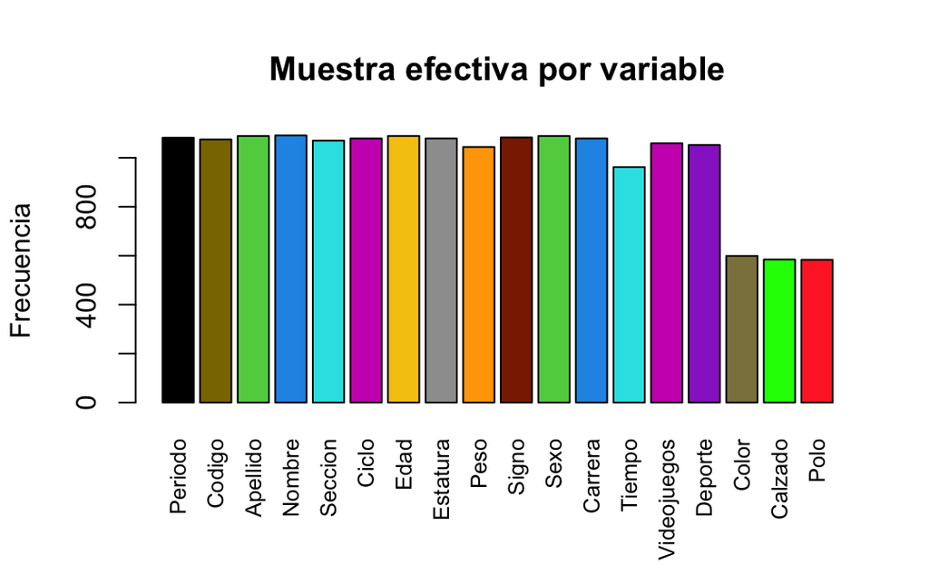

```r
# Gráfico de barras
barplot( tabla_ME
        ,main = "Muestra efectiva por variable"
        ,ylab = "Frecuencia"
        ,las = 3    # Sentido vertical del los nombres del eje x
        ,cex.names = 0.8  #Tamaño de las etiquetas en el eje x
        ,horiz = FALSE
        ,col = c("black","gold4",3,4,5,6,7,8,"orange","#8B2500",11,12,13,14,"#9932CC","#8B814C","green","#FF3030")
)
```

**Paleta de colores**:

https://r-charts.com/es/colores/  
https://myrbooksp.netlify.app/graph2.html

Hallando el porcentaje de casos o filas completas

```r
round(sum(complete.cases(Datos_Diversos_2)) / nrow(Datos_Diversos_2) *100 ,2)
```

```
[1] 43.13
```

El 43.13% de los filas están completas.

## 5.1 Sexo

```r
table(Datos_Diversos_2$Sexo, useNA = "always")
```

```
  70    F    m    M   mM   NB <NA>
   1  274    2  810    1    1   10
```

Aquí podríamos intentar corregir algunos errores, siempre y cuando estemos claros que estamos haciendo manipulación de datos.

```r
Datos_Diversos_2$Sexo[Datos_Diversos_2$Sexo == "mM"] <- "M"
Datos_Diversos_2$Sexo[Datos_Diversos_2$Sexo == "m"] <- "M"
Datos_Diversos_2$Sexo[Datos_Diversos_2$Sexo == "NB"] <- "M"
Datos_Diversos_2$Sexo[Datos_Diversos_2$Sexo == 70] <- "M"
```

```r
filter(Datos_Diversos_2, Sexo == "70")
```

| Periodo | Codigo | Apellido | Nombre | Seccion | Ciclo | Edad | Estatura | Peso | Signo | Sexo | Carrera | Tiempo | Videojuegos | Deporte | Color | Calzado | Polo |
| --- | --- | --- | --- | --- | --- | --- | --- | --- | --- | --- | --- | --- | --- | --- | --- | --- | --- |

```r
table(Datos_Diversos_2$Sexo, useNA = "always")
```

```
   F    M <NA>
 274  815   10
```

```r
table(Datos_Diversos_2$Sexo)
```

```
  F   M
274 815
```

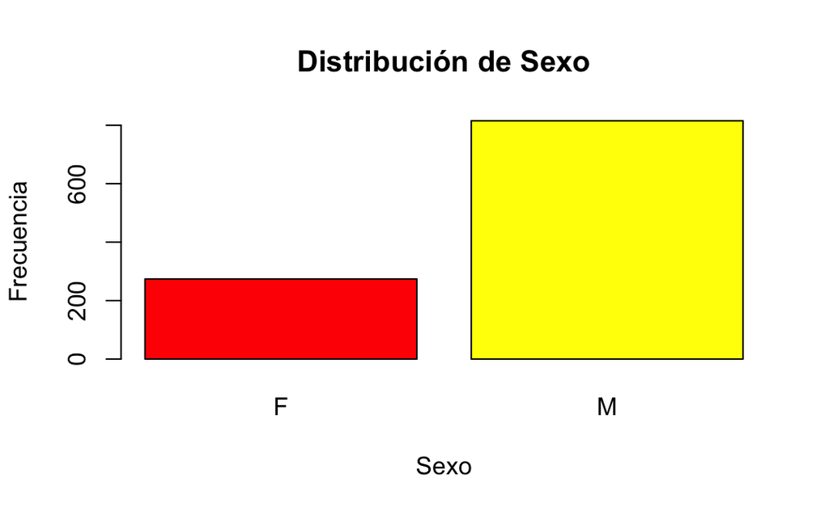

```r
# Diagrama de barras
barplot(
  table(Datos_Diversos_2$Sexo),     # Conteo de cada categoría
  ylab = "Frecuencia",              # Etiqueta del eje Y
  xlab = "Sexo",                    # Etiqueta del eje X
  main = "Distribución de Sexo",    # Título del gráfico
  col = c("red", "yellow"),         # Colores de las barras
  border = "black"                  # Bordes de las barras
)
```

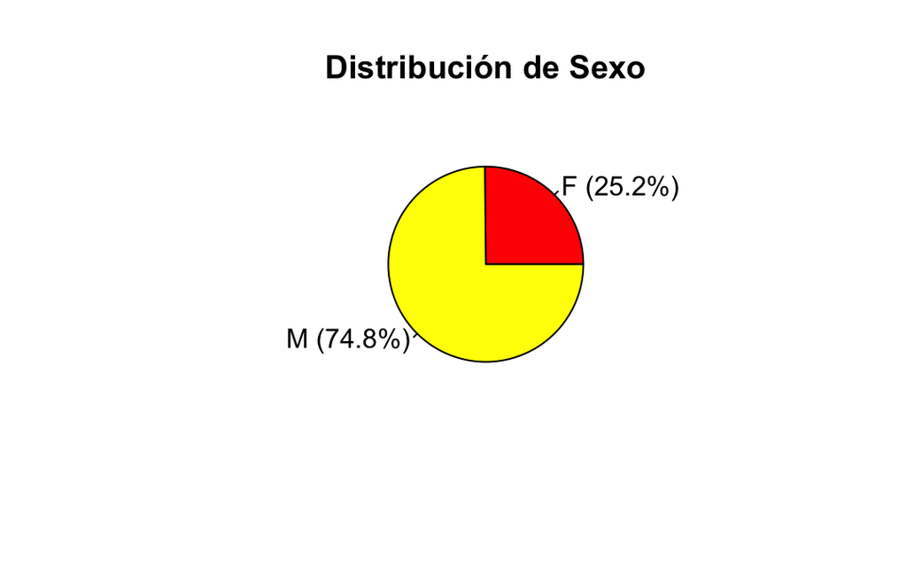

```r
# Grafico de Pie
pie(
  table(Datos_Diversos_2$Sexo),              # Conteo de cada categoría
  col = c("red", "yellow"),            # Colores más agradables
  main = "Distribución de Sexo",             # Título del gráfico
  labels = paste0(
    names(table(Datos_Diversos_2$Sexo)),     # Etiquetas (M, F, etc.)
    " (", round(100 * prop.table(table(Datos_Diversos_2$Sexo)), 1), "%)"
  )
)
```

## 5.2 Estatura (cm)

```r
summary(Datos_Diversos_2$Estatura)
```

```
   Min. 1st Qu.  Median    Mean 3rd Qu.    Max.    NA's
    1.2   160.0   170.0   149.2   175.0   203.0      20
```

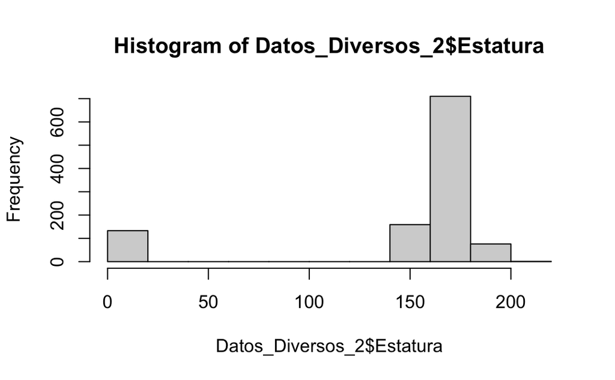

```r
# Histograma: Grafico para variables cuantitativas continuas
hist(Datos_Diversos_2$Estatura)
```

Revisando a los “enanitos”

```r
# Cantidad de personas con estatura menor a 50 cm.
sum(Datos_Diversos_2$Estatura < 50, na.rm = T)
```

```
[1] 133
```

```r
Datos_Diversos_2$Estatura[Datos_Diversos_2$Estatura < 50  & !is.na(Datos_Diversos_2$Estatura)] <- Datos_Diversos_2$Estatura[Datos_Diversos_2$Estatura < 50  & !is.na(Datos_Diversos_2$Estatura)]*100
```

```r
summary(Datos_Diversos_2$Estatura)
```

```
   Min. 1st Qu.  Median    Mean 3rd Qu.    Max.    NA's
  120.0   163.0   170.0   169.6   175.0   300.0      20
```

```r
sum(Datos_Diversos_2$Estatura > 250, na.rm = T)
```

```
[1] 1
```

```r
Datos_Diversos_2$Estatura[Datos_Diversos_2$Estatura == 300] <- NA
Datos_Diversos_2$Estatura[Datos_Diversos_2$Estatura == 120] <- NA
```

```r
summary(Datos_Diversos_2$Estatura)
```

```
   Min. 1st Qu.  Median    Mean 3rd Qu.    Max.    NA's
  148.0   163.0   170.0   169.5   175.0   203.0      22
```

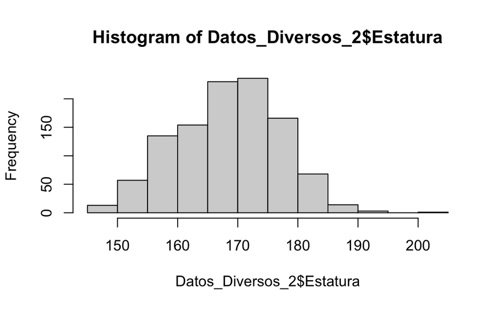

```r
hist(Datos_Diversos_2$Estatura)
```

## 5.3 Signo

```r
# Tabla ordenada
table(Datos_Diversos_2$Signo, useNA = "always") |>
  sort(decreasing = TRUE)
```

```
  Sagitario       Virgo       Aries Capricornio
        101          95          91          90
      Tauro       Libra     Acuario         Leo
         85          84          83          79
     Piscis    Escorpio      Cancer     Geminis
         72          67          56          45
    Géminis      Cáncer        <NA>       virgo
         31          22          16          13
      tauro     acuario capricornio     geminis
          7           4           4           4
        leo       libra      piscis           -
          4           4           4           3
      aries    escorpio   Escorpion     Gemenis
          3           3           3           3
  sagitario      cancer      cáncer  Capriornio
          3           2           2           2
      Picis         170       Arias CApricornio
          2           1           1           1
Desconocido       Leo ?      Ofiuco       picis
          1           1           1           1
    Pisicis      pisics       Pisis   Sagitatio
          1           1           1           1
      VIrgo
          1
```

Ordenar la tabla por orden de frecuencia nos permite atacar los problemas más grandes primero.

Vamos a hacer la limpieza con cuidado, trabajando primero sobre una copia y actualizando los cambios cuando estemos seguros.

```r
# Creando una copia
signo_limpio <- Datos_Diversos_2$Signo
```

Cantidad de signos

```r
# Cantidad de valores que tiene la variable
length(unique(signo_limpio))
```

```
[1] 45
```

```r
# Reemplaza las vocales con acento por sin acento
signo_limpio <- chartr("áéíóú", "aeiou", signo_limpio)
length(unique(signo_limpio))
```

```
[1] 42
```

```r
# Convertir todo a minúscula
signo_limpio <- tolower(signo_limpio)
length(unique(signo_limpio))
```

```
[1] 27
```

```r
sort(table(signo_limpio, useNA = "always"), decreasing = T)
```

```
signo_limpio
      virgo   sagitario capricornio       aries
        109         104          95          94
      tauro       libra     acuario         leo
         92          88          87          83
     cancer     geminis      piscis    escorpio
         82          80          76          70
       <NA>           -   escorpion     gemenis
         16           3           3           3
      picis  capriornio         170       arias
          3           2           1           1
desconocido       leo ?      ofiuco     pisicis
          1           1           1           1
     pisics       pisis   sagitatio
          1           1           1
```

```r
# Buscar usando patrones de palabras
unique(signo_limpio[grep("escor", signo_limpio)])
```

```
[1] "escorpio"  "escorpion"
```

```r
signo_limpio[grep("pis", signo_limpio)] <- "piscis"
signo_limpio[grep("cap", signo_limpio)] <- "capricornio"
signo_limpio[grep("leo", signo_limpio)] <- "leo"
signo_limpio[grep("escor", signo_limpio)] <- "escorpio"
```

```r
# Reemplazo usando valores puntuales o específicos
signo_limpio[signo_limpio == "ofiuco"] <- NA
signo_limpio[signo_limpio == "desconocido"] <- NA
signo_limpio[signo_limpio == 170] <- NA
signo_limpio[signo_limpio == "-"] <- NA
signo_limpio[signo_limpio == "sagitatio"] <- "sagitario"
signo_limpio[signo_limpio == "arias"] <- "aries"
signo_limpio[signo_limpio == "picis"] <- "piscis"
signo_limpio[signo_limpio == "gemenis"] <- "geminis"
```

```r
signo_limpio[is.na(signo_limpio)] <- "SinDatos"
```

```r
# Comprobando
 sort(table(signo_limpio, useNA = "always"), decreasing = T)
```

```
signo_limpio
      virgo   sagitario capricornio       aries
        109         105          97          95
      tauro       libra     acuario         leo
         92          88          87          84
    geminis      cancer      piscis    escorpio
         83          82          82          73
   SinDatos        <NA>
         22           0
```

```r
tabla_signo <- sort(round(prop.table(table(signo_limpio))*100, 2), decreasing = T)
tabla_signo
```

```
signo_limpio
      virgo   sagitario capricornio       aries
       9.92        9.55        8.83        8.64
      tauro       libra     acuario         leo
       8.37        8.01        7.92        7.64
    geminis      cancer      piscis    escorpio
       7.55        7.46        7.46        6.64
   SinDatos
       2.00
```

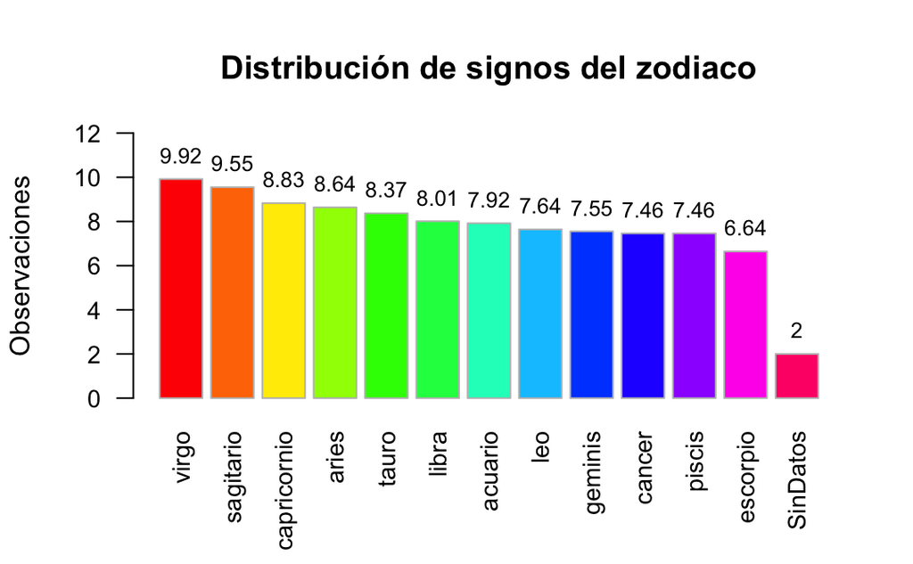

```r
# Crear gráfico de barras con tabla de frecuencias de signos
barras <- barplot(
  tabla_signo,
  las = 2,                      # Rotación de etiquetas eje X (2 = vertical, más legible que 3)
  cex.names = 0.9,              # Tamaño de etiquetas en eje X
  cex.axis = 0.9,               # Tamaño de valores en eje Y
  ylab = "Observaciones",       # Etiqueta eje Y
  main = "Distribución de signos del zodiaco", # Título más descriptivo
  ylim = c(0,12),
  col = rainbow(length(tabla_signo)), # Colores automáticos y diferenciables
  border = "gray"               # Bordes más suaves
)

# Añadir etiquetas de frecuencia sobre cada barra
text(
  x = barras,
  y = tabla_signo,
  labels = tabla_signo,
  cex = 0.8,
  pos = 3,                      # Posición arriba de la barra (más claro que pos=1)
  col = "black"                 # Color de texto más legible
)
```

```r
# Reemplazando la variable Signo por los datos corregidos
Datos_Diversos_2$Signo <- signo_limpio
table(Datos_Diversos_2$Signo)
```

```
    acuario       aries      cancer capricornio
         87          95          82          97
   escorpio     geminis         leo       libra
         73          83          84          88
     piscis   sagitario    SinDatos       tauro
         82         105          22          92
      virgo
        109
```

—– NOS QUEDAMOS AQUI ——–

## 5.4 Carrera

Total de carreras llenadas por los alumnos

```r
length(table(Datos_Diversos_2$Carrera))
```

```
[1] 130
```

Considerando que UTEC tiene cerca de 12 carreras, podemos ver que tenemos un problema.

```r
unique(Datos_Diversos_2$Carrera)
```

```
  [1] "Ing.Electrónica"
  [2] "Bioingenieria"
  [3] "Ing.Mecatronica"
  [4] "Ing. Industrial"
  [5] "Ing. Mecatronica"
  [6] "Ing. Mecatrónica"
  [7] "Ciencia de la Computación"
  [8] "Ing.Industrial"
  [9] "Ing. Civil"
 [10] "Ing Mecatronica"
 [11] "Ing. Mecánica"
 [12] "Ing. de la Energía"
 [13] "Ciencias de la Computación"
 [14] "Ciencias de la computación"
 [15] "Ciencias de la computacion"
```

[output cut: 116 more lines]

```r
sort(table(Datos_Diversos_2$Carrera, useNA = "always"), decreasing = T)
```

```
           Ing. Industrial              Bioingeniería
                        91                         86
 Ciencia de la Computación           Ing. Mecatrónica
                        74                         68
     Ingenieria Industrial                 Ing. Civil
                        40                         38
     Ingeniería Industrial     Ingeniería Mecatrónica
                        38                         37
            Ing. Ambiental              Bioingenieria
                        34                         32
          Ing. Mecatronica           Ingeniería Civil
                        30                         27
             Ing. Mecánica           Computer Science
                        26                         21
              Ing. Química                       <NA>
                        21                         20
Ciencias de la Computación        Ingeniería Mecánica
                        19                         19
          Ing. Electrónica           Ingenieria Civil
                        18                         18
             Ing. Mecanica Ciencias de la computación
                        17                         14
      Ingeniería Ambiental     Ingeniería Electrónica
                        14                         14
        Ingeniería Química             Ing.Industrial
                        14                         13
    Ingenieria Mecatronica  Ciencia de la Computacion
                        13                         10
 Ciencia de la computación   Ingeniería de la Energía
                         8                          8
            Ing Industrial         Ing. de la Energía
                         6                          6
                 Ing.Civil            Ing.Electrónica
                         6                          6
           Ing.Mecatronica            Ing.Mecatrónica
                         6                          6
      Ingenieria Ambiental        Ingenieria Mecanica
                         6                          6
          Ciencia de Datos           Ing. Electronica
                         5                          5
```

[output cut: 77 more lines]

```
                         1                          1
     Ingeniería Meatrónica        Ingenieria Mecáncia
                         1                          1
       Ingenieria mecanica        Ingeniería mecánica
                         1                          1
    Ingeniería mecatrónica         Ingeniería química
                         1                          1
           Ingeniria Civil      Ingenirieria mecanica
                         1                          1
     Ingienería Industrial     Ingieneria Mecatronica
                         1                          1
                       Leo                   Mecánica
                         1                          1
               mecatronica
                         1
```

Ordenara la tabla por orden de frecuencia nos permite atacar los problemas más grandes primero.

Vamos a hacer la limpieza con cuidado, trabajando primero sobre una copia y actualizando los cambios cuando estemos seguros.

Convirtiendo todo en minúscula usando la función `tolower`

```r
CarreraLimpia <- Datos_Diversos_2$Carrera
CarreraLimpia <- tolower(CarreraLimpia)  #Convirtiendo todo en minúscula
length(table(CarreraLimpia))
```

```
[1] 91
```

Hemos disminuido el numero de carreras.

Vamos a quitar todas las tildes y las colocaremos correctamente más tarde. Para eso usaremos la función `chartr`.

```r
CarreraLimpia <- chartr("áéíóú", "aeiou", CarreraLimpia)
length(table(CarreraLimpia))
```

```
[1] 63
```

Hemos disminuido las carreras un mas

```r
sort(table(CarreraLimpia, useNA = "always"), decreasing = T)
```

```
CarreraLimpia
             bioingenieria           ing. mecatronica
                       118                        101
 ciencia de la computacion            ing. industrial
                        94                         92
     ingenieria industrial     ingenieria mecatronica
                        85                         57
          ingenieria civil              ing. mecanica
                        51                         46
                ing. civil ciencias de la computacion
                        44                         41
            ing. ambiental        ingenieria mecanica
                        34                         32
          ing. electronica               ing. quimica
                        27                         26
      ingenieria ambiental     ingenieria electronica
                        25                         22
          computer science         ingenieria quimica
                        21                         20
                      <NA>            ing.mecatronica
                        20                         14
            ing.industrial         ing. de la energia
                        13                         10
  ingenieria de la energia             ing industrial
                        10                          8
              ing. energia           ciencia de datos
                         8                          7
                 ing.civil            ing.electronica
                         7                          6
             ing.ambiental               ing.mecanica
                         5                          5
         ing de la energia                mecatronica
                         4                          4
                     civil                         cs
                         2                          2
             ing ambiental               ing mecanica
                         2                          2
           ing mecatronica           ing, mecatronica
                         2                          2
               ing.energia            ingeneria civil
```

[output cut: 10 more lines]

```
                         1                          1
               ing.quimica        ingeneria ambiental
                         1                          1
   ingeneria de la energia      ingeneria mecatronica
                         1                          1
      ingenieria electrica         ingenieria energia
                         1                          1
     ingenieria meatronica        ingenieria mecancia
                         1                          1
           ingeniria civil      ingenirieria mecanica
                         1                          1
     ingieneria industrial     ingieneria mecatronica
                         1                          1
                       leo                   mecanica
                         1                          1
```

Ahora vamos a usar la función `grep` para corregir patrones un poco más complicados.

La función `grep` y sus variantes como `gsub` trabajan con expresiones regulares para encontrar patrones interesantes en las cadenas de caracteres.

Hay que saber un poco sobre expresiones regulares. Revisar la ayuda de `grep` para más información.

```r
unique(CarreraLimpia[grep("^ing.*[\\.\\ ,]", CarreraLimpia)])
```

```
 [1] "ing.electronica"          "ing.mecatronica"
 [3] "ing. industrial"          "ing. mecatronica"
 [5] "ing.industrial"           "ing. civil"
 [7] "ing mecatronica"          "ing. mecanica"
 [9] "ing. de la energia"       "ing.ambiental"
[11] "ing. ambiental"           "ing. energia"
[13] "ing. electronica"         "ing. quimica"
[15] "ing ambiental"            "ing.civil"
[17] "ingenieria mecatronica"   "ingenieria quimica"
[19] "ing.mecanica"             "ing industrial"
[21] "ingenieria civil"         "ing de la energia"
[23] "ingenieria ambiental"     "ing mecanica"
[25] "ing.quimica"              "ing. mecatonica"
[27] "ing, mecatronica"         "ing.civi"
[29] "ing. electrònica"         "ing.energia"
[31] "ingenieria industrial"    "ingenieria mecanica"
[33] "ingenieria electronica"   "ingenieria de la energia"
[35] "ingieneria mecatronica"   "ingeneria civil"
[37] "ingeniria civil"          "ingeneria mecatronica"
[39] "ingeneria ambiental"      "ingenieria energia"
[41] "ingenieria meatronica"    "ingenieria mecancia"
[43] "ingeneria de la energia"  "ingeneria industrial"
[45] "ingenieria electrica"     "ingieneria industrial"
[47] "ingenirieria mecanica"    "ingenireria industrial"
```

Hay casos de carreras que comienzan por las letras “ing” y eventualmente llegan a un espacio, un punto o una coma.

```r
unique(gsub("^ing*[\\.\\,]", "", CarreraLimpia))
```

```
 [1] "electronica"
 [2] "bioingenieria"
 [3] "mecatronica"
 [4] " industrial"
 [5] " mecatronica"
 [6] "ciencia de la computacion"
 [7] "industrial"
 [8] " civil"
 [9] "ing mecatronica"
[10] " mecanica"
[11] " de la energia"
[12] "ciencias de la computacion"
[13] "ambiental"
[14] " ambiental"
[15] " energia"
```

[output cut: 43 more lines]

```r
CarreraLimpia <- gsub("^ing.*[\\.\\,]", "", CarreraLimpia)
length(table(CarreraLimpia, useNA = "always"))
```

```
[1] 58
```

```r
length(table(CarreraLimpia, useNA = "always"))
```

```
[1] 58
```

Hemos reducido mas las carreras.

```r
sort(table(CarreraLimpia, useNA = "always"), decreasing = T)
```

```
CarreraLimpia
             bioingenieria                mecatronica
                       118                        103
 ciencia de la computacion                 industrial
                        94                         92
     ingenieria industrial     ingenieria mecatronica
                        85                         57
          ingenieria civil                   mecanica
                        51                         46
                     civil ciencias de la computacion
                        44                         41
                 ambiental        ingenieria mecanica
                        34                         32
               electronica                    quimica
                        27                         26
      ingenieria ambiental     ingenieria electronica
                        25                         22
          computer science         ingenieria quimica
                        21                         20
                      <NA>                mecatronica
                        20                         18
                industrial              de la energia
                        14                         10
  ingenieria de la energia                      civil
                        10                          9
                   energia             ing industrial
                         8                          8
          ciencia de datos                electronica
                         7                          7
                  mecanica                  ambiental
                         6                          5
         ing de la energia                         cs
                         4                          2
                   energia              ing ambiental
                         2                          2
              ing mecanica            ing mecatronica
                         2                          2
           ingeneria civil       ingeneria industrial
                         2                          2
    ingenireria industrial                electrònica
                         2                          1
                mecatonica              bioimgenieria
                         1                          1
            bioningenieria                       civi
                         1                          1
       igenieria ambiental        ingeneria ambiental
                         1                          1
   ingeneria de la energia      ingeneria mecatronica
                         1                          1
      ingenieria electrica         ingenieria energia
                         1                          1
     ingenieria meatronica        ingenieria mecancia
                         1                          1
           ingeniria civil      ingenirieria mecanica
                         1                          1
     ingieneria industrial     ingieneria mecatronica
                         1                          1
                       leo                    quimica
                         1                          1
```

Identifico el patrón

```r
unique(CarreraLimpia[grep("comput", CarreraLimpia)])
```

```
[1] "ciencia de la computacion"
[2] "ciencias de la computacion"
[3] "computer science"
```

```r
CarreraLimpia[grep("bio", CarreraLimpia)] <- "bioingenieria"
CarreraLimpia[grep("comput", CarreraLimpia)] <- "ciencia de la computacion"
CarreraLimpia[grep("elec", CarreraLimpia)] <- "electronica"
CarreraLimpia[grep("ambie", CarreraLimpia)] <- "ambiental"
CarreraLimpia[grep("mecan", CarreraLimpia)] <- "mecanica"
CarreraLimpia[grep("civi", CarreraLimpia)] <- "civil"
CarreraLimpia[grep("mecat", CarreraLimpia)] <- "mecatronica"
CarreraLimpia[grep("energ", CarreraLimpia)] <- "energia"
CarreraLimpia[grep("quimi", CarreraLimpia)] <- "quimica"
CarreraLimpia[grep("indu", CarreraLimpia)] <- "industrial"
CarreraLimpia[grep("datos", CarreraLimpia)] <- "ciencia de datos"
CarreraLimpia[grep("meatronica", CarreraLimpia)] <- "mecatronica"
```

Reemplazar usando palabras puntuales

```r
CarreraLimpia[CarreraLimpia == "cs"] <- "ciencia de la computacion"
CarreraLimpia[CarreraLimpia == "leo"] <- NA
#CarreraLimpia[CarreraLimpia == ""] <- NA
```

Comprobar el avance de los reemplazos

```r
length(table(CarreraLimpia, useNA = "always"))
```

```
[1] 12
```

```r
sort(table(CarreraLimpia, useNA = "always"), decreasing = T)
```

```
CarreraLimpia
               industrial               mecatronica
                      204                       184
ciencia de la computacion             bioingenieria
                      158                       120
                    civil                  mecanica
                      108                        88
                ambiental               electronica
                       68                        58
                  quimica                   energia
                       47                        36
                     <NA>          ciencia de datos
                       21                         7
```

Aparentemente la variable Carrera estaría limpia.

Veamos que las cosas quedaron bien:

```r
DataPrueba <- data.frame(Datos_Diversos_2$Carrera, CarreraLimpia)
DataPrueba
```

| Datos_Diversos_2.Carrera | CarreraLimpia |
| --- | --- |
| Ing.Electrónica | electronica |
| Bioingenieria | bioingenieria |
| Ing.Mecatronica | mecatronica |
| Ing. Industrial | industrial |
| Ing. Mecatronica | mecatronica |
| Ing. Mecatrónica | mecatronica |
| Ciencia de la Computación | ciencia de la computacion |
| Ciencia de la Computación | ciencia de la computacion |
| Ing. Mecatrónica | mecatronica |
| Ing.Industrial | industrial |

[output cut: 990 more lines]

```r
tablaCarr <- sort(table(CarreraLimpia, useNA = "always"), decreasing = T)
tablaCarr
```

```
CarreraLimpia
               industrial               mecatronica
                      204                       184
ciencia de la computacion             bioingenieria
                      158                       120
                    civil                  mecanica
                      108                        88
                ambiental               electronica
                       68                        58
                  quimica                   energia
                       47                        36
                     <NA>          ciencia de datos
                       21                         7
```

```r
GrafBarras <- barplot(tablaCarr
                      ,las = 3
                      ,cex.names = 0.8
                      ,cex.axis = 0.8
                      ,ylab = "Observaciones"
                      ,main = "Carreras - Datos diversos"
                      ,col = c(rep("gray",10),"red")
                      ,ylim = c(0,230)    )

text(x=GrafBarras
     ,y=tablaCarr
     ,label = tablaCarr
     ,cex = 0.8
     ,col = "brown"
     ,pos = 3)
```

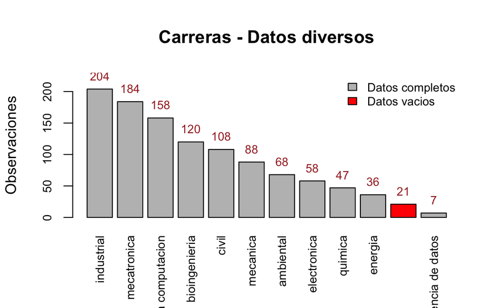

```r
legend("topright"
       ,legend = c("Datos completos","Datos vacios")
       ,fill = c("gray","red")
       ,bty = "n"
       ,cex = 0.8  )
```

Podemos suponer que la variable `Carrera` está suficientemente limpia y oficializamos los cambios.

```r
Datos_Diversos_2$Carrera <- CarreraLimpia
table(Datos_Diversos_2$Carrera, useNA = "always")
```

```
                ambiental             bioingenieria
                       68                       120
         ciencia de datos ciencia de la computacion
                        7                       158
                    civil               electronica
                      108                        58
                  energia                industrial
                       36                       204
                 mecanica               mecatronica
                       88                       184
                  quimica                      <NA>
                       47                        21
```

```r
Datos_Diversos_2 <- mutate_at(Datos_Diversos_2, c("Carrera"), ~replace(.,is.na(.), "SinDatos")) #Renombra los NA
table(Datos_Diversos_2$Carrera, useNA = "always")
```

```
                ambiental             bioingenieria
                       68                       120
         ciencia de datos ciencia de la computacion
                        7                       158
                    civil               electronica
                      108                        58
                  energia                industrial
                       36                       204
                 mecanica               mecatronica
                       88                       184
                  quimica                  SinDatos
                       47                        21
                     <NA>
                        0
```

## 5.5 Variable Peso

Convirtiendo la variable de `chr` a `num`

```r
str(Datos_Diversos_2)
```

```
tibble [1,099 × 18] (S3: tbl_df/tbl/data.frame)
 $ Periodo    : chr [1:1099] "2020.2" "2020.2" "2020.1" "2020.1" ...
 $ Codigo     : num [1:1099] 2.02e+08 2.02e+08 2.02e+08 2.02e+08 2.02e+08 ...
 $ Apellido   : chr [1:1099] "Chuquimajo Huamantumba" "Abad Rios" "Abanto Rodríguez" "Acevedo Loayza" ...
 $ Nombre     : chr [1:1099] "Pablo" "Alexandro" "Diego Walter" "Gina Tamarah" ...
 $ Seccion    : num [1:1099] 3 1 1 1 5 3 3 1 3 3 ...
 $ Ciclo      : chr [1:1099] "5" "6" "3" "5" ...
 $ Edad       : num [1:1099] 21 19 17 18 18 18 17 22 17 18 ...
 $ Estatura   : num [1:1099] 180 170 153 172 181 153 160 177 166 165 ...
 $ Peso       : chr [1:1099] "68" "63" "50" "74" ...
 $ Signo      : chr [1:1099] "geminis" "geminis" "escorpio" "aries" ...
 $ Sexo       : chr [1:1099] "M" "M" "M" "F" ...
 $ Carrera    : chr [1:1099] "electronica" "bioingenieria" "mecatronica" "industrial" ...
 $ Tiempo     : chr [1:1099] "300" NA "381" "381" ...
 $ Videojuegos: chr [1:1099] "no" "si" "No" "no" ...
 $ Deporte    : chr [1:1099] "no" "si" "No" "no" ...
 $ Color      : chr [1:1099] NA NA NA NA ...
 $ Calzado    : chr [1:1099] NA NA NA NA ...
 $ Polo       : chr [1:1099] NA NA NA NA ...
```

```r
unique(Datos_Diversos_2$Peso)
```

```
 [1] "68"                 "63"
 [3] "50"                 "74"
 [5] "81"                 "55"
 [7] "65"                 "62"
 [9] "51"                 "64"
[11] NA                   "95"
[13] "70"                 "80"
[15] "60"                 "57"
[17] "75"                 "56"
[19] "82"                 "104"
[21] "52"                 "79"
[23] "78"                 "76"
[25] "92"                 "73"
[27] "85"                 "88"
[29] "87"                 "66"
```

[output cut: 20 more lines]

```r
Datos_Diversos_2$Peso[Datos_Diversos_2$Peso == "90k"] <- 90
unique(Datos_Diversos_2$Peso)
```

```
 [1] "68"                 "63"
 [3] "50"                 "74"
 [5] "81"                 "55"
 [7] "65"                 "62"
 [9] "51"                 "64"
[11] NA                   "95"
[13] "70"                 "80"
[15] "60"                 "57"
[17] "75"                 "56"
[19] "82"                 "104"
[21] "52"                 "79"
[23] "78"                 "76"
[25] "92"                 "73"
[27] "85"                 "88"
[29] "87"                 "66"
```

[output cut: 20 more lines]

```r
str(Datos_Diversos_2$Peso)
```

```
 chr [1:1099] "68" "63" "50" "74" "81" "55" "65" "62" ...
```

```r
Datos_Diversos_2$Peso <- as.numeric(Datos_Diversos_2$Peso)
str(Datos_Diversos_2$Peso)
```

```
 num [1:1099] 68 63 50 74 81 55 65 62 68 51 ...
```

## 5.6 Variable Codigo

Convirtiendo la variable de `mun` a `chr`

```r
Datos_Diversos_2$Codigo <- as.character(Datos_Diversos_2$Codigo)
str(Datos_Diversos_2)
```

```
tibble [1,099 × 18] (S3: tbl_df/tbl/data.frame)
 $ Periodo    : chr [1:1099] "2020.2" "2020.2" "2020.1" "2020.1" ...
 $ Codigo     : chr [1:1099] "201810033" "201810647" "201910052" "201810713" ...
 $ Apellido   : chr [1:1099] "Chuquimajo Huamantumba" "Abad Rios" "Abanto Rodríguez" "Acevedo Loayza" ...
 $ Nombre     : chr [1:1099] "Pablo" "Alexandro" "Diego Walter" "Gina Tamarah" ...
 $ Seccion    : num [1:1099] 3 1 1 1 5 3 3 1 3 3 ...
 $ Ciclo      : chr [1:1099] "5" "6" "3" "5" ...
 $ Edad       : num [1:1099] 21 19 17 18 18 18 17 22 17 18 ...
 $ Estatura   : num [1:1099] 180 170 153 172 181 153 160 177 166 165 ...
 $ Peso       : num [1:1099] 68 63 50 74 81 55 65 62 68 51 ...
 $ Signo      : chr [1:1099] "geminis" "geminis" "escorpio" "aries" ...
 $ Sexo       : chr [1:1099] "M" "M" "M" "F" ...
 $ Carrera    : chr [1:1099] "electronica" "bioingenieria" "mecatronica" "industrial" ...
 $ Tiempo     : chr [1:1099] "300" NA "381" "381" ...
 $ Videojuegos: chr [1:1099] "no" "si" "No" "no" ...
 $ Deporte    : chr [1:1099] "no" "si" "No" "no" ...
 $ Color      : chr [1:1099] NA NA NA NA ...
 $ Calzado    : chr [1:1099] NA NA NA NA ...
 $ Polo       : chr [1:1099] NA NA NA NA ...
```

# 6 Eliminando los NA

```r
sum(is.na(Datos_Diversos_2$Codigo))
```

```
[1] 24
```

```r
library(dplyr)
Datos_Diversos_3 <- filter(Datos_Diversos_2, is.na(Codigo) == FALSE)
sum(is.na(Datos_Diversos_3$Codigo))
```

```
[1] 0
```